# examples_0112

Let quadratic function $f$ be defined below:

$$f(x)~=~x^{2}+{6}x-{207}$$

When curve $y=f(x)$ is graphed, we see two $x$-intercepts at $(x_1,0)$ and $(x_2,0)$.

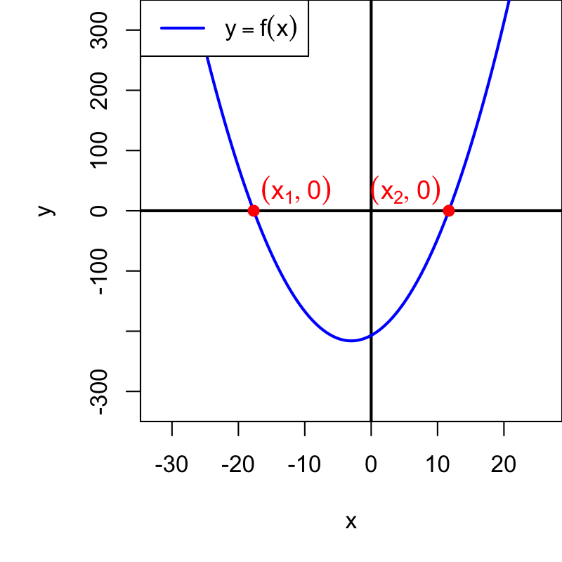

In exact form, those $x$ intercepts can be expressed as $h\pm p\sqrt{q}$.

$$x_1=h-p\sqrt{q}$$
$$x_2=h+p\sqrt{q}$$

Find the values of $h$, $p$, and $q$.

$h=$

$p=$

$q=$

The $x$ intercepts occur when either $x_1$ or $x_2$ satisfies $f(x)=0$.

$$x^{2}+{6}x-{207}=0$$

Identify the coefficients.

$$a=1$$
$$b=6$$
$$c=-207$$

Plug numbers into the quadratic formula!

$$x =
\frac{-(6)\pm\sqrt{(6)^2-4(1)(-207)}}{2(1)}$$

Simplify.

$$x = \frac{-6 \pm
\sqrt{36-(-828)}}{2}$$

Simplify.

$$x = \frac{-6 \pm
\sqrt{864}}{2}$$

Use prime factorization.

$$x = \frac{-6 \pm
\sqrt{2\cdot2\cdot2\cdot2\cdot2\cdot3\cdot3\cdot3}}{2}$$

Isolate the twin factors.

$$x = \frac{-6 \pm
\sqrt{2\cdot2\cdot2\cdot2\cdot3\cdot3}\cdot
\sqrt{2\cdot3}}{2}$$

Simplify the square root of the square.

$$x = \frac{-6 \pm 2\cdot2\cdot3\cdot
\sqrt{2\cdot3}}{2}$$

Simplify the integer products.

$$x = \frac{-6 \pm 12\cdot
\sqrt{6}}{2}$$

Split the fraction.

$$x = \frac{-6}{2} \pm \frac{12\cdot
\sqrt{6}}{2}$$

Both numerators contain a factor of 2.

$$x = -3 \pm 6\sqrt{6}$$

So, $h=-3$ and $p=6$ and $q=6$.

I should mention this means we could now write the function in **factored form**.

$$f(x)~=~\left[x-(-3-6\sqrt{6})\right]\cdot\left[x-(-3+6\sqrt{6})\right]$$

Let quadratic function $f$ be defined below:

$$f(x)~=~x^{2}-{10}x-{23}$$

When curve $y=f(x)$ is graphed, we see two $x$-intercepts at $(x_1,0)$ and $(x_2,0)$.

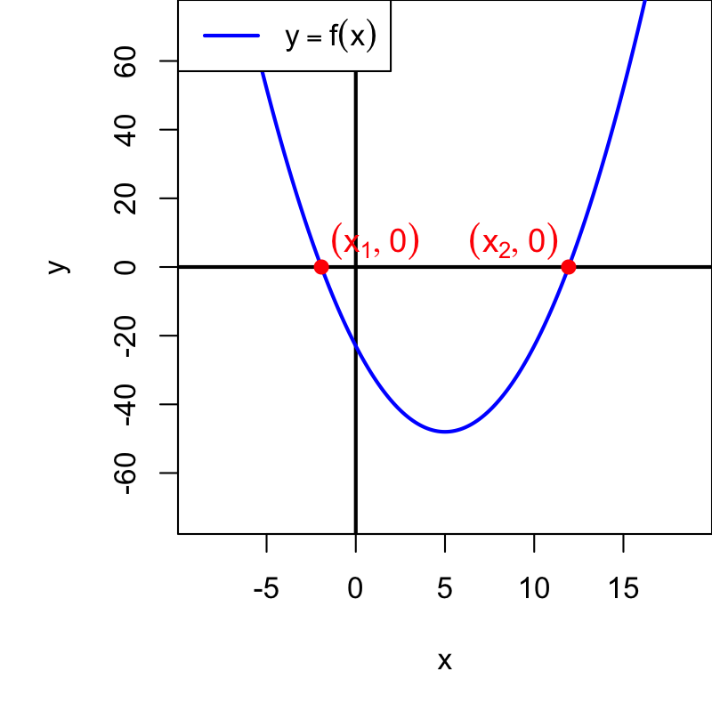

In exact form, those $x$ intercepts can be expressed as $h\pm p\sqrt{q}$.

$$x_1=h-p\sqrt{q}$$
$$x_2=h+p\sqrt{q}$$

Find the values of $h$, $p$, and $q$.

$h=$

$p=$

$q=$

The $x$ intercepts occur when either $x_1$ or $x_2$ satisfies $f(x)=0$.

$$x^{2}-{10}x-{23}=0$$

Identify the coefficients.

$$a=1$$
$$b=-10$$
$$c=-23$$

Plug numbers into the quadratic formula!

$$x =
\frac{-(-10)\pm\sqrt{(-10)^2-4(1)(-23)}}{2(1)}$$

Simplify.

$$x = \frac{10 \pm
\sqrt{100-(-92)}}{2}$$

Simplify.

$$x = \frac{10 \pm
\sqrt{192}}{2}$$

Use prime factorization.

$$x = \frac{10 \pm
\sqrt{2\cdot2\cdot2\cdot2\cdot2\cdot2\cdot3}}{2}$$

Isolate the twin factors.

$$x = \frac{10 \pm
\sqrt{2\cdot2\cdot2\cdot2\cdot2\cdot2}\cdot \sqrt{3}}{2}$$

Simplify the square root of the square.

$$x = \frac{10 \pm 2\cdot2\cdot2\cdot
\sqrt{3}}{2}$$

Simplify the integer products.

$$x = \frac{10 \pm 8\cdot
\sqrt{3}}{2}$$

Split the fraction.

$$x = \frac{10}{2} \pm \frac{8\cdot
\sqrt{3}}{2}$$

Both numerators contain a factor of 2.

$$x = 5 \pm 4\sqrt{3}$$

So, $h=5$ and $p=4$ and $q=3$.

I should mention this means we could now write the function in **factored form**.

$$f(x)~=~\left[x-(5-4\sqrt{3})\right]\cdot\left[x-(5+4\sqrt{3})\right]$$

Let quadratic function $f$ be defined below:

$$f(x)~=~x^{2}+{10}x-{55}$$

When curve $y=f(x)$ is graphed, we see two $x$-intercepts at $(x_1,0)$ and $(x_2,0)$.

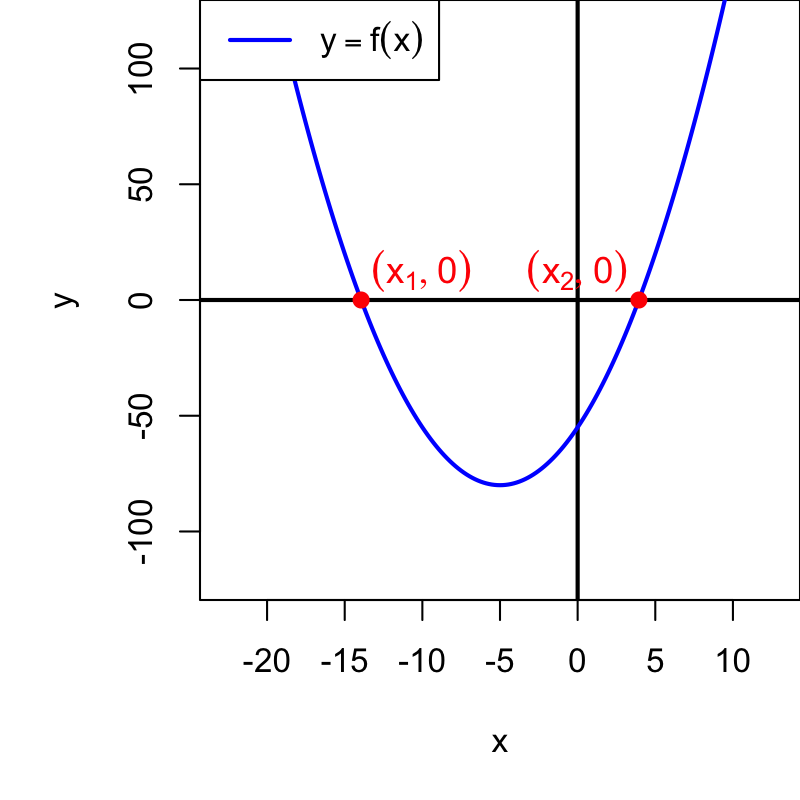

In exact form, those $x$ intercepts can be expressed as $h\pm p\sqrt{q}$.

$$x_1=h-p\sqrt{q}$$
$$x_2=h+p\sqrt{q}$$

Find the values of $h$, $p$, and $q$.

$h=$

$p=$

$q=$

The $x$ intercepts occur when either $x_1$ or $x_2$ satisfies $f(x)=0$.

$$x^{2}+{10}x-{55}=0$$

Identify the coefficients.

$$a=1$$
$$b=10$$
$$c=-55$$

Plug numbers into the quadratic formula!

$$x =
\frac{-(10)\pm\sqrt{(10)^2-4(1)(-55)}}{2(1)}$$

Simplify.

$$x = \frac{-10 \pm
\sqrt{100-(-220)}}{2}$$

Simplify.

$$x = \frac{-10 \pm
\sqrt{320}}{2}$$

Use prime factorization.

$$x = \frac{-10 \pm
\sqrt{2\cdot2\cdot2\cdot2\cdot2\cdot2\cdot5}}{2}$$

Isolate the twin factors.

$$x = \frac{-10 \pm
\sqrt{2\cdot2\cdot2\cdot2\cdot2\cdot2}\cdot \sqrt{5}}{2}$$

Simplify the square root of the square.

$$x = \frac{-10 \pm 2\cdot2\cdot2\cdot
\sqrt{5}}{2}$$

Simplify the integer products.

$$x = \frac{-10 \pm 8\cdot
\sqrt{5}}{2}$$

Split the fraction.

$$x = \frac{-10}{2} \pm \frac{8\cdot
\sqrt{5}}{2}$$

Both numerators contain a factor of 2.

$$x = -5 \pm 4\sqrt{5}$$

So, $h=-5$ and $p=4$ and $q=5$.

I should mention this means we could now write the function in **factored form**.

$$f(x)~=~\left[x-(-5-4\sqrt{5})\right]\cdot\left[x-(-5+4\sqrt{5})\right]$$

Let quadratic function $f$ be defined below:

$$f(x)~=~x^{2}-{4}x-{23}$$

When curve $y=f(x)$ is graphed, we see two $x$-intercepts at $(x_1,0)$ and $(x_2,0)$.

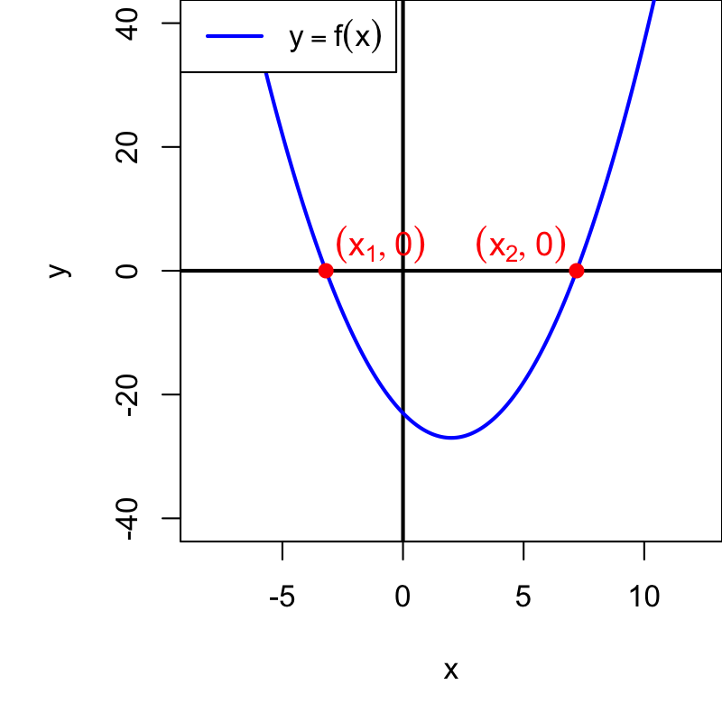

In exact form, those $x$ intercepts can be expressed as $h\pm p\sqrt{q}$.

$$x_1=h-p\sqrt{q}$$
$$x_2=h+p\sqrt{q}$$

Find the values of $h$, $p$, and $q$.

$h=$

$p=$

$q=$

The $x$ intercepts occur when either $x_1$ or $x_2$ satisfies $f(x)=0$.

$$x^{2}-{4}x-{23}=0$$

Identify the coefficients.

$$a=1$$
$$b=-4$$
$$c=-23$$

Plug numbers into the quadratic formula!

$$x =
\frac{-(-4)\pm\sqrt{(-4)^2-4(1)(-23)}}{2(1)}$$

Simplify.

$$x = \frac{4 \pm
\sqrt{16-(-92)}}{2}$$

Simplify.

$$x = \frac{4 \pm
\sqrt{108}}{2}$$

Use prime factorization.

$$x = \frac{4 \pm
\sqrt{2\cdot2\cdot3\cdot3\cdot3}}{2}$$

Isolate the twin factors.

$$x = \frac{4 \pm
\sqrt{2\cdot2\cdot3\cdot3}\cdot \sqrt{3}}{2}$$

Simplify the square root of the square.

$$x = \frac{4 \pm 2\cdot3\cdot
\sqrt{3}}{2}$$

Simplify the integer products.

$$x = \frac{4 \pm 6\cdot
\sqrt{3}}{2}$$

Split the fraction.

$$x = \frac{4}{2} \pm \frac{6\cdot
\sqrt{3}}{2}$$

Both numerators contain a factor of 2.

$$x = 2 \pm 3\sqrt{3}$$

So, $h=2$ and $p=3$ and $q=3$.

I should mention this means we could now write the function in **factored form**.

$$f(x)~=~\left[x-(2-3\sqrt{3})\right]\cdot\left[x-(2+3\sqrt{3})\right]$$

Let quadratic function $f$ be defined below:

$$f(x)~=~x^{2}+{4}x-{8}$$

When curve $y=f(x)$ is graphed, we see two $x$-intercepts at $(x_1,0)$ and $(x_2,0)$.

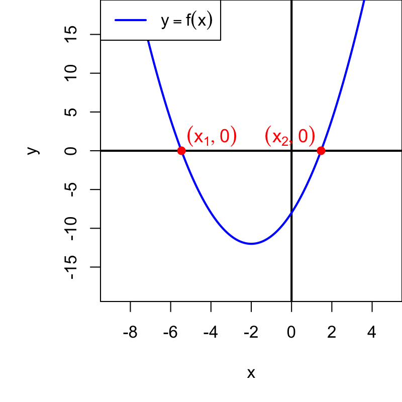

In exact form, those $x$ intercepts can be expressed as $h\pm p\sqrt{q}$.

$$x_1=h-p\sqrt{q}$$
$$x_2=h+p\sqrt{q}$$

Find the values of $h$, $p$, and $q$.

$h=$

$p=$

$q=$

The $x$ intercepts occur when either $x_1$ or $x_2$ satisfies $f(x)=0$.

$$x^{2}+{4}x-{8}=0$$

Identify the coefficients.

$$a=1$$
$$b=4$$
$$c=-8$$

Plug numbers into the quadratic formula!

$$x =
\frac{-(4)\pm\sqrt{(4)^2-4(1)(-8)}}{2(1)}$$

Simplify.

$$x = \frac{-4 \pm
\sqrt{16-(-32)}}{2}$$

Simplify.

$$x = \frac{-4 \pm
\sqrt{48}}{2}$$

Use prime factorization.

$$x = \frac{-4 \pm
\sqrt{2\cdot2\cdot2\cdot2\cdot3}}{2}$$

Isolate the twin factors.

$$x = \frac{-4 \pm
\sqrt{2\cdot2\cdot2\cdot2}\cdot \sqrt{3}}{2}$$

Simplify the square root of the square.

$$x = \frac{-4 \pm 2\cdot2\cdot
\sqrt{3}}{2}$$

Simplify the integer products.

$$x = \frac{-4 \pm 4\cdot
\sqrt{3}}{2}$$

Split the fraction.

$$x = \frac{-4}{2} \pm \frac{4\cdot
\sqrt{3}}{2}$$

Both numerators contain a factor of 2.

$$x = -2 \pm 2\sqrt{3}$$

So, $h=-2$ and $p=2$ and $q=3$.

I should mention this means we could now write the function in **factored form**.

$$f(x)~=~\left[x-(-2-2\sqrt{3})\right]\cdot\left[x-(-2+2\sqrt{3})\right]$$

Let quadratic function $f$ be defined below:

$$f(x)~=~x^{2}-{10}x-{20}$$

When curve $y=f(x)$ is graphed, we see two $x$-intercepts at $(x_1,0)$ and $(x_2,0)$.

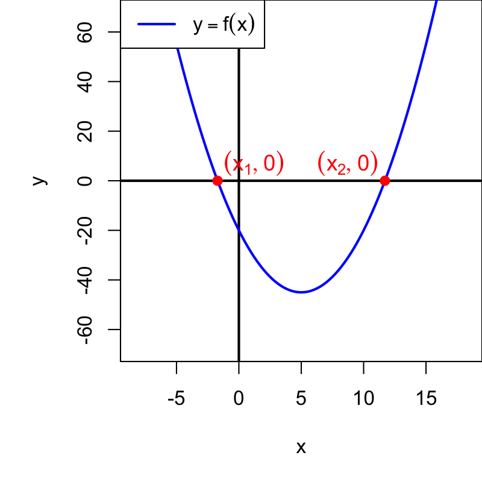

In exact form, those $x$ intercepts can be expressed as $h\pm p\sqrt{q}$.

$$x_1=h-p\sqrt{q}$$
$$x_2=h+p\sqrt{q}$$

Find the values of $h$, $p$, and $q$.

$h=$

$p=$

$q=$

The $x$ intercepts occur when either $x_1$ or $x_2$ satisfies $f(x)=0$.

$$x^{2}-{10}x-{20}=0$$

Identify the coefficients.

$$a=1$$
$$b=-10$$
$$c=-20$$

Plug numbers into the quadratic formula!

$$x =
\frac{-(-10)\pm\sqrt{(-10)^2-4(1)(-20)}}{2(1)}$$

Simplify.

$$x = \frac{10 \pm
\sqrt{100-(-80)}}{2}$$

Simplify.

$$x = \frac{10 \pm
\sqrt{180}}{2}$$

Use prime factorization.

$$x = \frac{10 \pm
\sqrt{2\cdot2\cdot3\cdot3\cdot5}}{2}$$

Isolate the twin factors.

$$x = \frac{10 \pm
\sqrt{2\cdot2\cdot3\cdot3}\cdot \sqrt{5}}{2}$$

Simplify the square root of the square.

$$x = \frac{10 \pm 2\cdot3\cdot
\sqrt{5}}{2}$$

Simplify the integer products.

$$x = \frac{10 \pm 6\cdot
\sqrt{5}}{2}$$

Split the fraction.

$$x = \frac{10}{2} \pm \frac{6\cdot
\sqrt{5}}{2}$$

Both numerators contain a factor of 2.

$$x = 5 \pm 3\sqrt{5}$$

So, $h=5$ and $p=3$ and $q=5$.

I should mention this means we could now write the function in **factored form**.

$$f(x)~=~\left[x-(5-3\sqrt{5})\right]\cdot\left[x-(5+3\sqrt{5})\right]$$

Let quadratic function $f$ be defined below:

$$f(x)~=~x^{2}-{6}x-{3}$$

When curve $y=f(x)$ is graphed, we see two $x$-intercepts at $(x_1,0)$ and $(x_2,0)$.

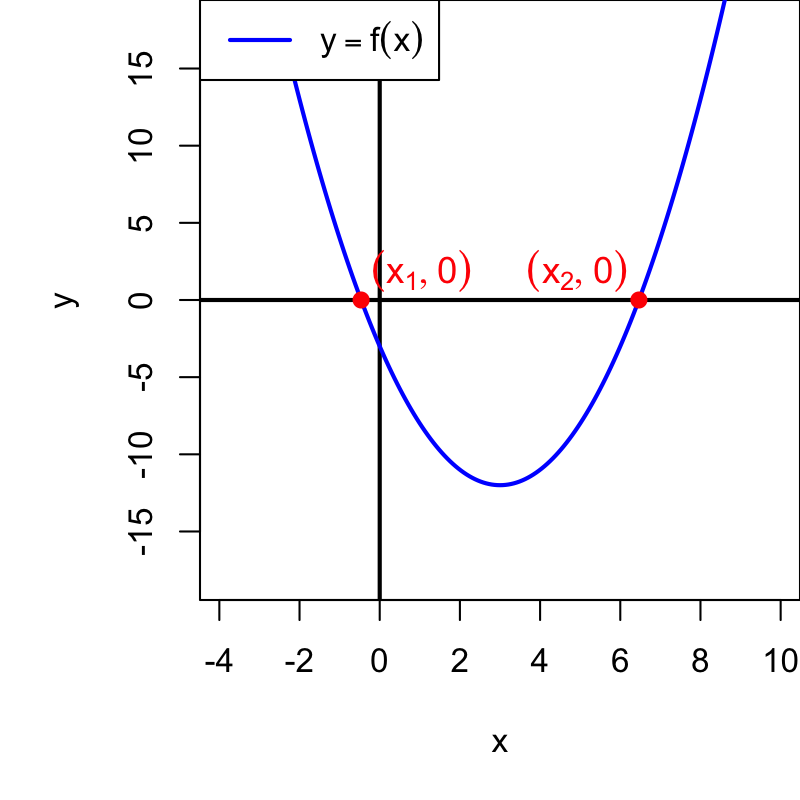

In exact form, those $x$ intercepts can be expressed as $h\pm p\sqrt{q}$.

$$x_1=h-p\sqrt{q}$$
$$x_2=h+p\sqrt{q}$$

Find the values of $h$, $p$, and $q$.

$h=$

$p=$

$q=$

The $x$ intercepts occur when either $x_1$ or $x_2$ satisfies $f(x)=0$.

$$x^{2}-{6}x-{3}=0$$

Identify the coefficients.

$$a=1$$
$$b=-6$$
$$c=-3$$

Plug numbers into the quadratic formula!

$$x =
\frac{-(-6)\pm\sqrt{(-6)^2-4(1)(-3)}}{2(1)}$$

Simplify.

$$x = \frac{6 \pm
\sqrt{36-(-12)}}{2}$$

Simplify.

$$x = \frac{6 \pm
\sqrt{48}}{2}$$

Use prime factorization.

$$x = \frac{6 \pm
\sqrt{2\cdot2\cdot2\cdot2\cdot3}}{2}$$

Isolate the twin factors.

$$x = \frac{6 \pm
\sqrt{2\cdot2\cdot2\cdot2}\cdot \sqrt{3}}{2}$$

Simplify the square root of the square.

$$x = \frac{6 \pm 2\cdot2\cdot
\sqrt{3}}{2}$$

Simplify the integer products.

$$x = \frac{6 \pm 4\cdot
\sqrt{3}}{2}$$

Split the fraction.

$$x = \frac{6}{2} \pm \frac{4\cdot
\sqrt{3}}{2}$$

Both numerators contain a factor of 2.

$$x = 3 \pm 2\sqrt{3}$$

So, $h=3$ and $p=2$ and $q=3$.

I should mention this means we could now write the function in **factored form**.

$$f(x)~=~\left[x-(3-2\sqrt{3})\right]\cdot\left[x-(3+2\sqrt{3})\right]$$

Let quadratic function $f$ be defined below:

$$f(x)~=~x^{2}+{4}x-{4}$$

When curve $y=f(x)$ is graphed, we see two $x$-intercepts at $(x_1,0)$ and $(x_2,0)$.

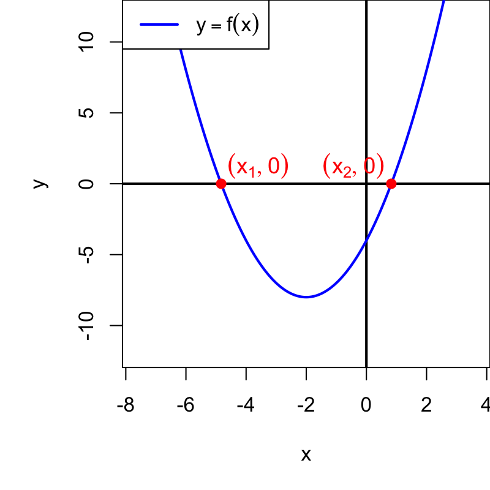

In exact form, those $x$ intercepts can be expressed as $h\pm p\sqrt{q}$.

$$x_1=h-p\sqrt{q}$$
$$x_2=h+p\sqrt{q}$$

Find the values of $h$, $p$, and $q$.

$h=$

$p=$

$q=$

The $x$ intercepts occur when either $x_1$ or $x_2$ satisfies $f(x)=0$.

$$x^{2}+{4}x-{4}=0$$

Identify the coefficients.

$$a=1$$
$$b=4$$
$$c=-4$$

Plug numbers into the quadratic formula!

$$x =
\frac{-(4)\pm\sqrt{(4)^2-4(1)(-4)}}{2(1)}$$

Simplify.

$$x = \frac{-4 \pm
\sqrt{16-(-16)}}{2}$$

Simplify.

$$x = \frac{-4 \pm
\sqrt{32}}{2}$$

Use prime factorization.

$$x = \frac{-4 \pm
\sqrt{2\cdot2\cdot2\cdot2\cdot2}}{2}$$

Isolate the twin factors.

$$x = \frac{-4 \pm
\sqrt{2\cdot2\cdot2\cdot2}\cdot \sqrt{2}}{2}$$

Simplify the square root of the square.

$$x = \frac{-4 \pm 2\cdot2\cdot
\sqrt{2}}{2}$$

Simplify the integer products.

$$x = \frac{-4 \pm 4\cdot
\sqrt{2}}{2}$$

Split the fraction.

$$x = \frac{-4}{2} \pm \frac{4\cdot
\sqrt{2}}{2}$$

Both numerators contain a factor of 2.

$$x = -2 \pm 2\sqrt{2}$$

So, $h=-2$ and $p=2$ and $q=2$.

I should mention this means we could now write the function in **factored form**.

$$f(x)~=~\left[x-(-2-2\sqrt{2})\right]\cdot\left[x-(-2+2\sqrt{2})\right]$$

Let quadratic function $f$ be defined below:

$$f(x)~=~x^{2}+{10}x-{2}$$

When curve $y=f(x)$ is graphed, we see two $x$-intercepts at $(x_1,0)$ and $(x_2,0)$.

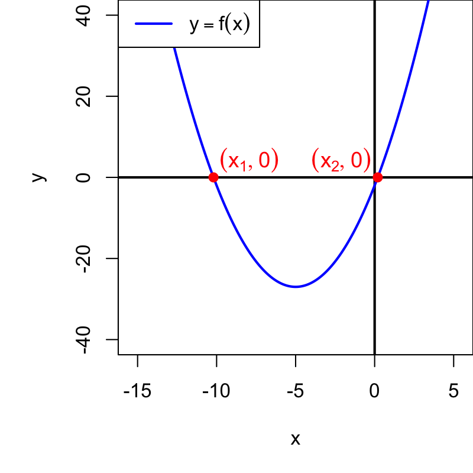

In exact form, those $x$ intercepts can be expressed as $h\pm p\sqrt{q}$.

$$x_1=h-p\sqrt{q}$$
$$x_2=h+p\sqrt{q}$$

Find the values of $h$, $p$, and $q$.

$h=$

$p=$

$q=$

The $x$ intercepts occur when either $x_1$ or $x_2$ satisfies $f(x)=0$.

$$x^{2}+{10}x-{2}=0$$

Identify the coefficients.

$$a=1$$
$$b=10$$
$$c=-2$$

Plug numbers into the quadratic formula!

$$x =
\frac{-(10)\pm\sqrt{(10)^2-4(1)(-2)}}{2(1)}$$

Simplify.

$$x = \frac{-10 \pm
\sqrt{100-(-8)}}{2}$$

Simplify.

$$x = \frac{-10 \pm
\sqrt{108}}{2}$$

Use prime factorization.

$$x = \frac{-10 \pm
\sqrt{2\cdot2\cdot3\cdot3\cdot3}}{2}$$

Isolate the twin factors.

$$x = \frac{-10 \pm
\sqrt{2\cdot2\cdot3\cdot3}\cdot \sqrt{3}}{2}$$

Simplify the square root of the square.

$$x = \frac{-10 \pm 2\cdot3\cdot
\sqrt{3}}{2}$$

Simplify the integer products.

$$x = \frac{-10 \pm 6\cdot
\sqrt{3}}{2}$$

Split the fraction.

$$x = \frac{-10}{2} \pm \frac{6\cdot
\sqrt{3}}{2}$$

Both numerators contain a factor of 2.

$$x = -5 \pm 3\sqrt{3}$$

So, $h=-5$ and $p=3$ and $q=3$.

I should mention this means we could now write the function in **factored form**.

$$f(x)~=~\left[x-(-5-3\sqrt{3})\right]\cdot\left[x-(-5+3\sqrt{3})\right]$$

Let quadratic function $f$ be defined below:

$$f(x)~=~x^{2}-{18}x+{36}$$

When curve $y=f(x)$ is graphed, we see two $x$-intercepts at $(x_1,0)$ and $(x_2,0)$.

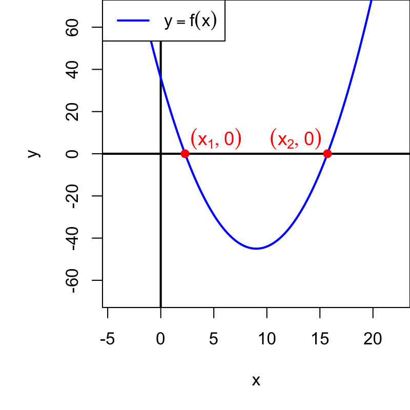

In exact form, those $x$ intercepts can be expressed as $h\pm p\sqrt{q}$.

$$x_1=h-p\sqrt{q}$$
$$x_2=h+p\sqrt{q}$$

Find the values of $h$, $p$, and $q$.

$h=$

$p=$

$q=$

The $x$ intercepts occur when either $x_1$ or $x_2$ satisfies $f(x)=0$.

$$x^{2}-{18}x+{36}=0$$

Identify the coefficients.

$$a=1$$
$$b=-18$$
$$c=36$$

Plug numbers into the quadratic formula!

$$x =
\frac{-(-18)\pm\sqrt{(-18)^2-4(1)(36)}}{2(1)}$$

Simplify.

$$x = \frac{18 \pm
\sqrt{324-(144)}}{2}$$

Simplify.

$$x = \frac{18 \pm
\sqrt{180}}{2}$$

Use prime factorization.

$$x = \frac{18 \pm
\sqrt{2\cdot2\cdot3\cdot3\cdot5}}{2}$$

Isolate the twin factors.

$$x = \frac{18 \pm
\sqrt{2\cdot2\cdot3\cdot3}\cdot \sqrt{5}}{2}$$

Simplify the square root of the square.

$$x = \frac{18 \pm 2\cdot3\cdot
\sqrt{5}}{2}$$

Simplify the integer products.

$$x = \frac{18 \pm 6\cdot
\sqrt{5}}{2}$$

Split the fraction.

$$x = \frac{18}{2} \pm \frac{6\cdot
\sqrt{5}}{2}$$

Both numerators contain a factor of 2.

$$x = 9 \pm 3\sqrt{5}$$

So, $h=9$ and $p=3$ and $q=5$.

I should mention this means we could now write the function in **factored form**.

$$f(x)~=~\left[x-(9-3\sqrt{5})\right]\cdot\left[x-(9+3\sqrt{5})\right]$$

A quadratic function, $f$, has zeros at $(x_1,0)$ and $(x_2,0)$.

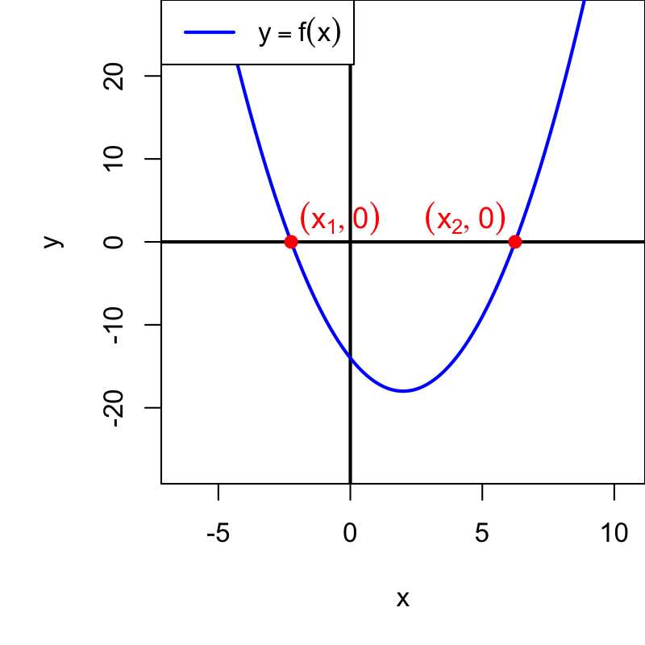

The exact zeros are $2\pm 3\sqrt{2}$.

$$x_1~=~2-3\sqrt{2}$$
$$x_2~=~2+3\sqrt{2}$$

The function $f$ can be expressed in **factored form**, with parameter $a$ adjusting the vertical stretch and orientation of the parabola.

$$f(x)~=~a\cdot
\left[x-(2-3\sqrt{2})\right]\cdot\left[x-(2+3\sqrt{2})\right]$$

The function, expressed in **standard form**, is parameterized with quadratic coefficient $a$, linear coefficient $b$, and constant $c$.

$$f(x)~=~ax^2+bx+c$$

In this case, the quadratic coefficient equals 1.

$$a=1$$

Find the linear coefficient and the constant. You can do this by expanding the factored form and combining like terms.

$b=$

$c=$

Start in factored form. We know $a=1$.

$$f(x)~=~\left[x-(2-3\sqrt{2})\right]\cdot\left[x-(2+3\sqrt{2})\right]$$

At this point, you can either FOIL or distribute away the inside parentheses. I think it'll be a bit cleaner to distribute the subtraction across the parentheses.

$$\left[x-2+3\sqrt{2}\right]\cdot\left[x-2-3\sqrt{2}\right]$$

But now, instead of FOIL, we need to generalize, because each factor has three terms: a linear term and two constant terms. You could probably guess that we simply multiply each of the first factor's terms by each of the second factor's terms.

$$x^2-2x-3\sqrt{2}x-2x+4+6\sqrt{2}+3\sqrt{2}x-6\sqrt{2}-18$$

Combine like terms. Opposite terms cancel each other out.

$$x^2-4x-14$$

Thus, $b=-4$ and $c=-14$.

A quadratic function, $f$, has zeros at $(x_1,0)$ and $(x_2,0)$.

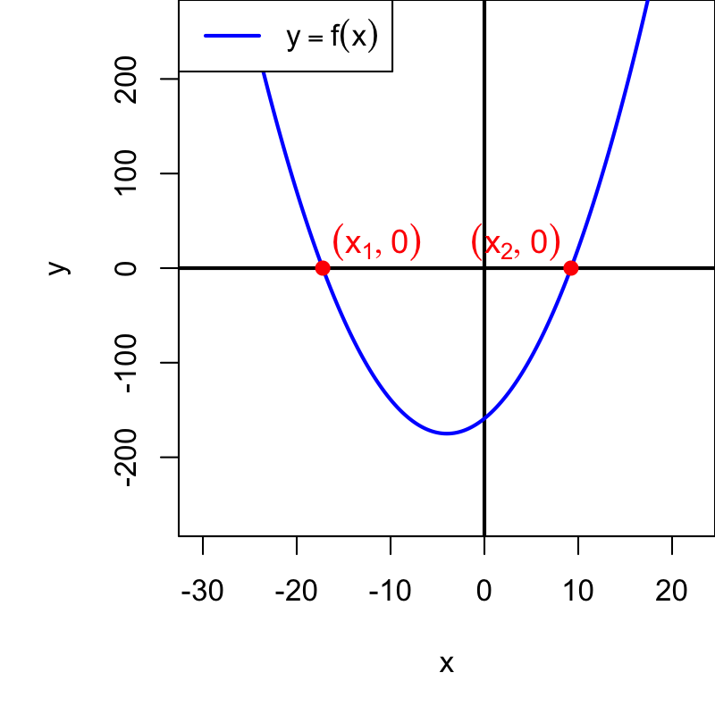

The exact zeros are $-4\pm 5\sqrt{7}$.

$$x_1~=~-4-5\sqrt{7}$$
$$x_2~=~-4+5\sqrt{7}$$

The function $f$ can be expressed in **factored form**, with parameter $a$ adjusting the vertical stretch and orientation of the parabola.

$$f(x)~=~a\cdot
\left[x-(-4-5\sqrt{7})\right]\cdot\left[x-(-4+5\sqrt{7})\right]$$

The function, expressed in **standard form**, is parameterized with quadratic coefficient $a$, linear coefficient $b$, and constant $c$.

$$f(x)~=~ax^2+bx+c$$

In this case, the quadratic coefficient equals 1.

$$a=1$$

Find the linear coefficient and the constant. You can do this by expanding the factored form and combining like terms.

$b=$

$c=$

Start in factored form. We know $a=1$.

$$f(x)~=~\left[x-(-4-5\sqrt{7})\right]\cdot\left[x-(-4+5\sqrt{7})\right]$$

At this point, you can either FOIL or distribute away the inside parentheses. I think it'll be a bit cleaner to distribute the subtraction across the parentheses.

$$\left[x+4+5\sqrt{7}\right]\cdot\left[x+4-5\sqrt{7}\right]$$

But now, instead of FOIL, we need to generalize, because each factor has three terms: a linear term and two constant terms. You could probably guess that we simply multiply each of the first factor's terms by each of the second factor's terms.

$$x^2+4x-5\sqrt{7}x+4x+16-20\sqrt{7}+5\sqrt{7}x+20\sqrt{7}-175$$

Combine like terms. Opposite terms cancel each other out.

$$x^2+8x-159$$

Thus, $b=8$ and $c=-159$.

A quadratic function, $f$, has zeros at $(x_1,0)$ and $(x_2,0)$.

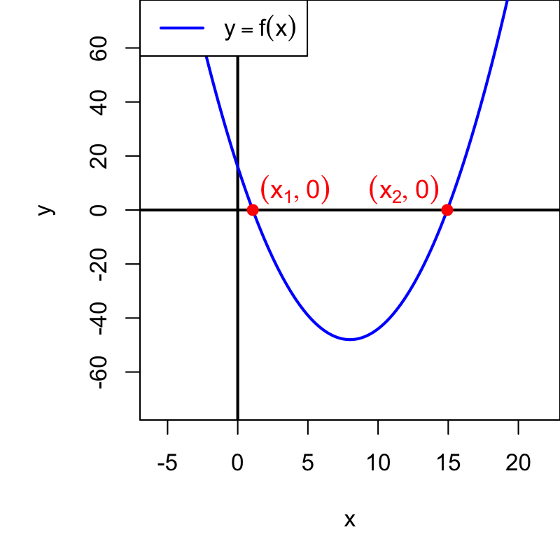

The exact zeros are $8\pm 4\sqrt{3}$.

$$x_1~=~8-4\sqrt{3}$$
$$x_2~=~8+4\sqrt{3}$$

The function $f$ can be expressed in **factored form**, with parameter $a$ adjusting the vertical stretch and orientation of the parabola.

$$f(x)~=~a\cdot
\left[x-(8-4\sqrt{3})\right]\cdot\left[x-(8+4\sqrt{3})\right]$$

The function, expressed in **standard form**, is parameterized with quadratic coefficient $a$, linear coefficient $b$, and constant $c$.

$$f(x)~=~ax^2+bx+c$$

In this case, the quadratic coefficient equals 1.

$$a=1$$

Find the linear coefficient and the constant. You can do this by expanding the factored form and combining like terms.

$b=$

$c=$

Start in factored form. We know $a=1$.

$$f(x)~=~\left[x-(8-4\sqrt{3})\right]\cdot\left[x-(8+4\sqrt{3})\right]$$

At this point, you can either FOIL or distribute away the inside parentheses. I think it'll be a bit cleaner to distribute the subtraction across the parentheses.

$$\left[x-8+4\sqrt{3}\right]\cdot\left[x-8-4\sqrt{3}\right]$$

But now, instead of FOIL, we need to generalize, because each factor has three terms: a linear term and two constant terms. You could probably guess that we simply multiply each of the first factor's terms by each of the second factor's terms.

$$x^2-8x-4\sqrt{3}x-8x+64+32\sqrt{3}+4\sqrt{3}x-32\sqrt{3}-48$$

Combine like terms. Opposite terms cancel each other out.

$$x^2-16x+16$$

Thus, $b=-16$ and $c=16$.

A quadratic function, $f$, has zeros at $(x_1,0)$ and $(x_2,0)$.

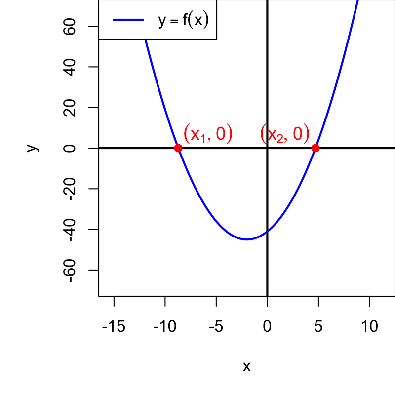

The exact zeros are $-2\pm 3\sqrt{5}$.

$$x_1~=~-2-3\sqrt{5}$$
$$x_2~=~-2+3\sqrt{5}$$

The function $f$ can be expressed in **factored form**, with parameter $a$ adjusting the vertical stretch and orientation of the parabola.

$$f(x)~=~a\cdot
\left[x-(-2-3\sqrt{5})\right]\cdot\left[x-(-2+3\sqrt{5})\right]$$

The function, expressed in **standard form**, is parameterized with quadratic coefficient $a$, linear coefficient $b$, and constant $c$.

$$f(x)~=~ax^2+bx+c$$

In this case, the quadratic coefficient equals 1.

$$a=1$$

Find the linear coefficient and the constant. You can do this by expanding the factored form and combining like terms.

$b=$

$c=$

Start in factored form. We know $a=1$.

$$f(x)~=~\left[x-(-2-3\sqrt{5})\right]\cdot\left[x-(-2+3\sqrt{5})\right]$$

At this point, you can either FOIL or distribute away the inside parentheses. I think it'll be a bit cleaner to distribute the subtraction across the parentheses.

$$\left[x+2+3\sqrt{5}\right]\cdot\left[x+2-3\sqrt{5}\right]$$

But now, instead of FOIL, we need to generalize, because each factor has three terms: a linear term and two constant terms. You could probably guess that we simply multiply each of the first factor's terms by each of the second factor's terms.

$$x^2+2x-3\sqrt{5}x+2x+4-6\sqrt{5}+3\sqrt{5}x+6\sqrt{5}-45$$

Combine like terms. Opposite terms cancel each other out.

$$x^2+4x-41$$

Thus, $b=4$ and $c=-41$.

A quadratic function, $f$, has zeros at $(x_1,0)$ and $(x_2,0)$.

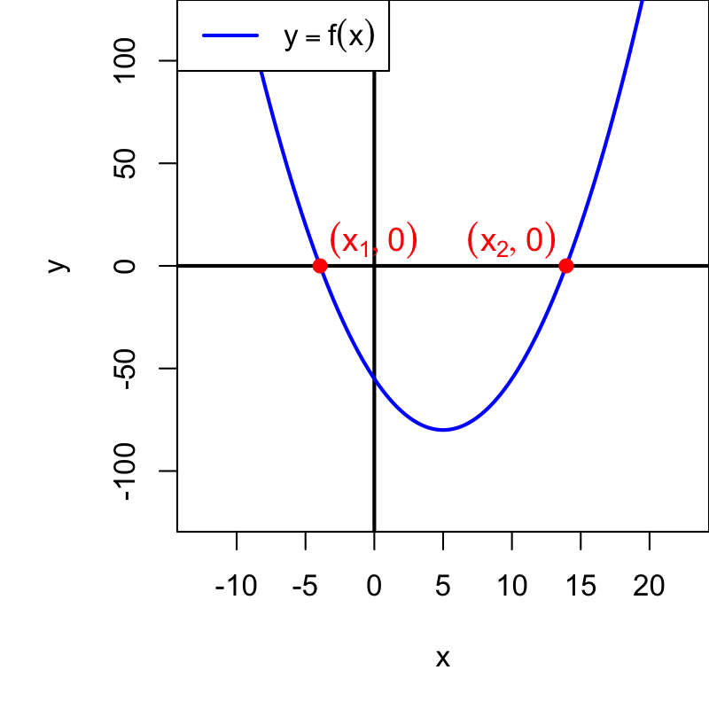

The exact zeros are $5\pm 4\sqrt{5}$.

$$x_1~=~5-4\sqrt{5}$$
$$x_2~=~5+4\sqrt{5}$$

The function $f$ can be expressed in **factored form**, with parameter $a$ adjusting the vertical stretch and orientation of the parabola.

$$f(x)~=~a\cdot
\left[x-(5-4\sqrt{5})\right]\cdot\left[x-(5+4\sqrt{5})\right]$$

The function, expressed in **standard form**, is parameterized with quadratic coefficient $a$, linear coefficient $b$, and constant $c$.

$$f(x)~=~ax^2+bx+c$$

In this case, the quadratic coefficient equals 1.

$$a=1$$

Find the linear coefficient and the constant. You can do this by expanding the factored form and combining like terms.

$b=$

$c=$

Start in factored form. We know $a=1$.

$$f(x)~=~\left[x-(5-4\sqrt{5})\right]\cdot\left[x-(5+4\sqrt{5})\right]$$

At this point, you can either FOIL or distribute away the inside parentheses. I think it'll be a bit cleaner to distribute the subtraction across the parentheses.

$$\left[x-5+4\sqrt{5}\right]\cdot\left[x-5-4\sqrt{5}\right]$$

But now, instead of FOIL, we need to generalize, because each factor has three terms: a linear term and two constant terms. You could probably guess that we simply multiply each of the first factor's terms by each of the second factor's terms.

$$x^2-5x-4\sqrt{5}x-5x+25+20\sqrt{5}+4\sqrt{5}x-20\sqrt{5}-80$$

Combine like terms. Opposite terms cancel each other out.

$$x^2-10x-55$$

Thus, $b=-10$ and $c=-55$.

A quadratic function, $f$, has zeros at $(x_1,0)$ and $(x_2,0)$.

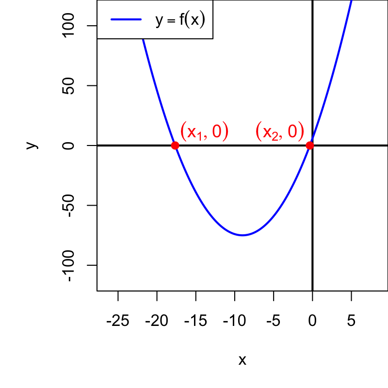

The exact zeros are $-9\pm 5\sqrt{3}$.

$$x_1~=~-9-5\sqrt{3}$$
$$x_2~=~-9+5\sqrt{3}$$

The function $f$ can be expressed in **factored form**, with parameter $a$ adjusting the vertical stretch and orientation of the parabola.

$$f(x)~=~a\cdot
\left[x-(-9-5\sqrt{3})\right]\cdot\left[x-(-9+5\sqrt{3})\right]$$

The function, expressed in **standard form**, is parameterized with quadratic coefficient $a$, linear coefficient $b$, and constant $c$.

$$f(x)~=~ax^2+bx+c$$

In this case, the quadratic coefficient equals 1.

$$a=1$$

Find the linear coefficient and the constant. You can do this by expanding the factored form and combining like terms.

$b=$

$c=$

Start in factored form. We know $a=1$.

$$f(x)~=~\left[x-(-9-5\sqrt{3})\right]\cdot\left[x-(-9+5\sqrt{3})\right]$$

At this point, you can either FOIL or distribute away the inside parentheses. I think it'll be a bit cleaner to distribute the subtraction across the parentheses.

$$\left[x+9+5\sqrt{3}\right]\cdot\left[x+9-5\sqrt{3}\right]$$

But now, instead of FOIL, we need to generalize, because each factor has three terms: a linear term and two constant terms. You could probably guess that we simply multiply each of the first factor's terms by each of the second factor's terms.

$$x^2+9x-5\sqrt{3}x+9x+81-45\sqrt{3}+5\sqrt{3}x+45\sqrt{3}-75$$

Combine like terms. Opposite terms cancel each other out.

$$x^2+18x+6$$

Thus, $b=18$ and $c=6$.

A quadratic function, $f$, has zeros at $(x_1,0)$ and $(x_2,0)$.

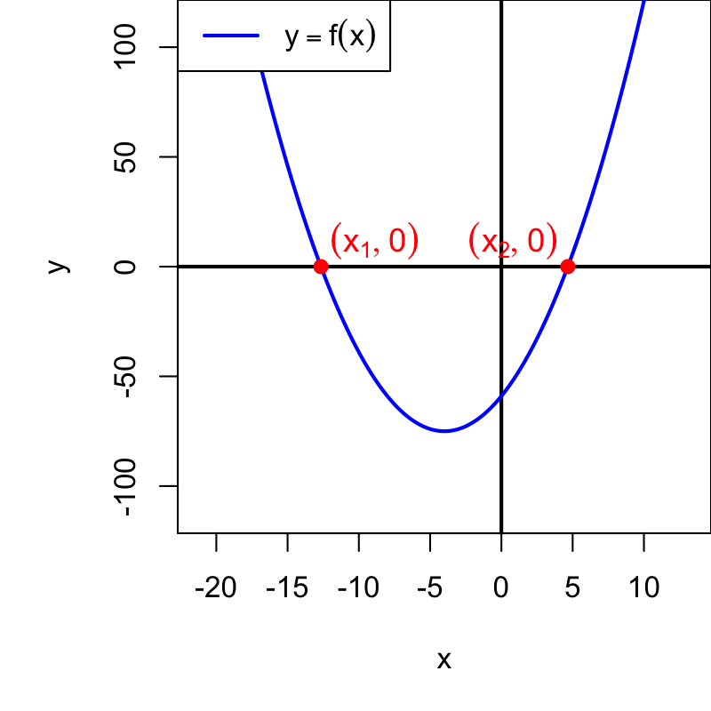

The exact zeros are $-4\pm 5\sqrt{3}$.

$$x_1~=~-4-5\sqrt{3}$$
$$x_2~=~-4+5\sqrt{3}$$

The function $f$ can be expressed in **factored form**, with parameter $a$ adjusting the vertical stretch and orientation of the parabola.

$$f(x)~=~a\cdot
\left[x-(-4-5\sqrt{3})\right]\cdot\left[x-(-4+5\sqrt{3})\right]$$

The function, expressed in **standard form**, is parameterized with quadratic coefficient $a$, linear coefficient $b$, and constant $c$.

$$f(x)~=~ax^2+bx+c$$

In this case, the quadratic coefficient equals 1.

$$a=1$$

Find the linear coefficient and the constant. You can do this by expanding the factored form and combining like terms.

$b=$

$c=$

Start in factored form. We know $a=1$.

$$f(x)~=~\left[x-(-4-5\sqrt{3})\right]\cdot\left[x-(-4+5\sqrt{3})\right]$$

At this point, you can either FOIL or distribute away the inside parentheses. I think it'll be a bit cleaner to distribute the subtraction across the parentheses.

$$\left[x+4+5\sqrt{3}\right]\cdot\left[x+4-5\sqrt{3}\right]$$

But now, instead of FOIL, we need to generalize, because each factor has three terms: a linear term and two constant terms. You could probably guess that we simply multiply each of the first factor's terms by each of the second factor's terms.

$$x^2+4x-5\sqrt{3}x+4x+16-20\sqrt{3}+5\sqrt{3}x+20\sqrt{3}-75$$

Combine like terms. Opposite terms cancel each other out.

$$x^2+8x-59$$

Thus, $b=8$ and $c=-59$.

A quadratic function, $f$, has zeros at $(x_1,0)$ and $(x_2,0)$.

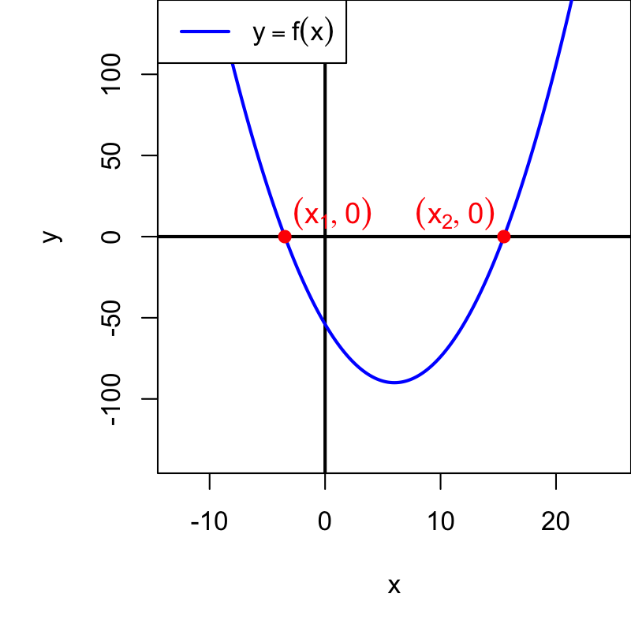

The exact zeros are $6\pm 3\sqrt{10}$.

$$x_1~=~6-3\sqrt{10}$$
$$x_2~=~6+3\sqrt{10}$$

The function $f$ can be expressed in **factored form**, with parameter $a$ adjusting the vertical stretch and orientation of the parabola.

$$f(x)~=~a\cdot
\left[x-(6-3\sqrt{10})\right]\cdot\left[x-(6+3\sqrt{10})\right]$$

The function, expressed in **standard form**, is parameterized with quadratic coefficient $a$, linear coefficient $b$, and constant $c$.

$$f(x)~=~ax^2+bx+c$$

In this case, the quadratic coefficient equals 1.

$$a=1$$

Find the linear coefficient and the constant. You can do this by expanding the factored form and combining like terms.

$b=$

$c=$

Start in factored form. We know $a=1$.

$$f(x)~=~\left[x-(6-3\sqrt{10})\right]\cdot\left[x-(6+3\sqrt{10})\right]$$

At this point, you can either FOIL or distribute away the inside parentheses. I think it'll be a bit cleaner to distribute the subtraction across the parentheses.

$$\left[x-6+3\sqrt{10}\right]\cdot\left[x-6-3\sqrt{10}\right]$$

But now, instead of FOIL, we need to generalize, because each factor has three terms: a linear term and two constant terms. You could probably guess that we simply multiply each of the first factor's terms by each of the second factor's terms.

$$x^2-6x-3\sqrt{10}x-6x+36+18\sqrt{10}+3\sqrt{10}x-18\sqrt{10}-90$$

Combine like terms. Opposite terms cancel each other out.

$$x^2-12x-54$$

Thus, $b=-12$ and $c=-54$.

A quadratic function, $f$, has zeros at $(x_1,0)$ and $(x_2,0)$.

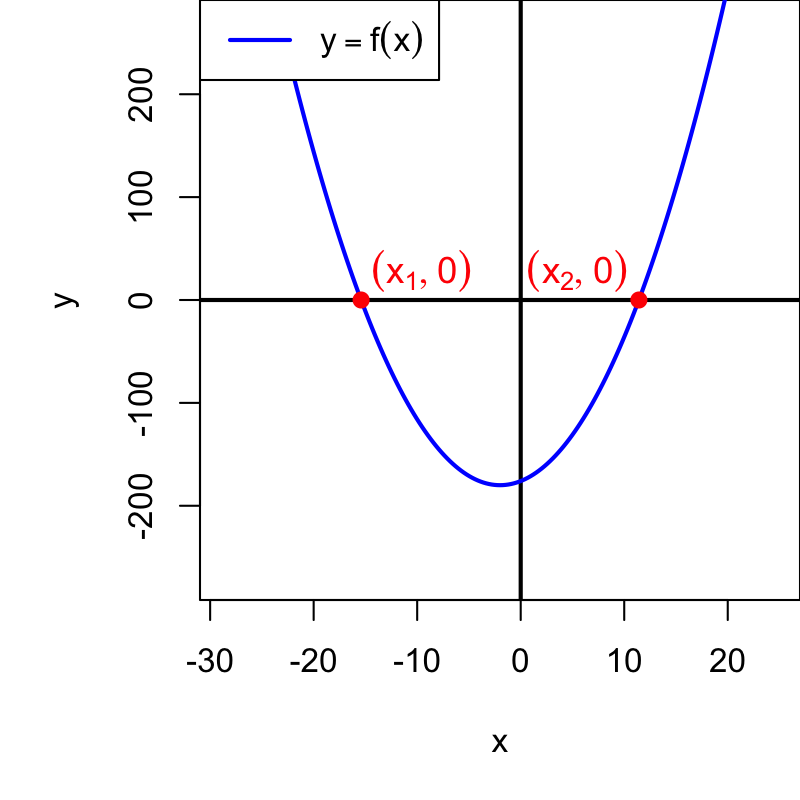

The exact zeros are $-2\pm 6\sqrt{5}$.

$$x_1~=~-2-6\sqrt{5}$$
$$x_2~=~-2+6\sqrt{5}$$

The function $f$ can be expressed in **factored form**, with parameter $a$ adjusting the vertical stretch and orientation of the parabola.

$$f(x)~=~a\cdot
\left[x-(-2-6\sqrt{5})\right]\cdot\left[x-(-2+6\sqrt{5})\right]$$

The function, expressed in **standard form**, is parameterized with quadratic coefficient $a$, linear coefficient $b$, and constant $c$.

$$f(x)~=~ax^2+bx+c$$

In this case, the quadratic coefficient equals 1.

$$a=1$$

Find the linear coefficient and the constant. You can do this by expanding the factored form and combining like terms.

$b=$

$c=$

Start in factored form. We know $a=1$.

$$f(x)~=~\left[x-(-2-6\sqrt{5})\right]\cdot\left[x-(-2+6\sqrt{5})\right]$$

At this point, you can either FOIL or distribute away the inside parentheses. I think it'll be a bit cleaner to distribute the subtraction across the parentheses.

$$\left[x+2+6\sqrt{5}\right]\cdot\left[x+2-6\sqrt{5}\right]$$

But now, instead of FOIL, we need to generalize, because each factor has three terms: a linear term and two constant terms. You could probably guess that we simply multiply each of the first factor's terms by each of the second factor's terms.

$$x^2+2x-6\sqrt{5}x+2x+4-12\sqrt{5}+6\sqrt{5}x+12\sqrt{5}-180$$

Combine like terms. Opposite terms cancel each other out.

$$x^2+4x-176$$

Thus, $b=4$ and $c=-176$.

A quadratic function, $f$, has zeros at $(x_1,0)$ and $(x_2,0)$.

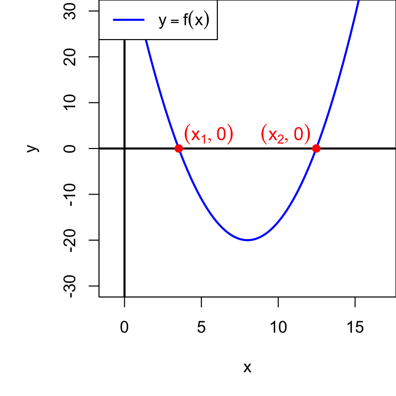

The exact zeros are $8\pm 2\sqrt{5}$.

$$x_1~=~8-2\sqrt{5}$$
$$x_2~=~8+2\sqrt{5}$$

The function $f$ can be expressed in **factored form**, with parameter $a$ adjusting the vertical stretch and orientation of the parabola.

$$f(x)~=~a\cdot
\left[x-(8-2\sqrt{5})\right]\cdot\left[x-(8+2\sqrt{5})\right]$$

The function, expressed in **standard form**, is parameterized with quadratic coefficient $a$, linear coefficient $b$, and constant $c$.

$$f(x)~=~ax^2+bx+c$$

In this case, the quadratic coefficient equals 1.

$$a=1$$

Find the linear coefficient and the constant. You can do this by expanding the factored form and combining like terms.

$b=$

$c=$

Start in factored form. We know $a=1$.

$$f(x)~=~\left[x-(8-2\sqrt{5})\right]\cdot\left[x-(8+2\sqrt{5})\right]$$

At this point, you can either FOIL or distribute away the inside parentheses. I think it'll be a bit cleaner to distribute the subtraction across the parentheses.

$$\left[x-8+2\sqrt{5}\right]\cdot\left[x-8-2\sqrt{5}\right]$$

But now, instead of FOIL, we need to generalize, because each factor has three terms: a linear term and two constant terms. You could probably guess that we simply multiply each of the first factor's terms by each of the second factor's terms.

$$x^2-8x-2\sqrt{5}x-8x+64+16\sqrt{5}+2\sqrt{5}x-16\sqrt{5}-20$$

Combine like terms. Opposite terms cancel each other out.

$$x^2-16x+44$$

Thus, $b=-16$ and $c=44$.

Find the solutions to the quadratic equation below.
$$z^{2} - 12 z + 85=0$$

Both solutions will be complex numbers (because the discriminant is negative). To find the solutions, I'd recommend using [this website](https://samuelj.li/complex-function-plotter/#z%5E2-12*z%2B85), which uses [domain coloring](https://en.wikipedia.org/wiki/Domain_coloring) to visualize the solutions. By default the solutions will appear as the center of concentric rings.

Whenever a quadratic equation with REAL coefficients has COMPLEX solutions, the two solutions are [complex conjugates](https://en.wikipedia.org/wiki/Complex_conjugate). In other words, the solutions can be expressed as $x=h-wi$ and $x=h+wi$, where $i=\sqrt{-1}$. Find $h$ and $w$.

$h=$

$w=$

Use [this website](https://samuelj.li/complex-function-plotter/#z%5E2-12*z%2B85). It should automatically have the function typed in.

Zoom out. Notice two "circles". Zoom into a circle to find the real component $h$ and the imaginary component $w$. You will find solutions at $6-7i$ and $6+7i$. So,

$$h=6$$
$$w=7$$

Find the solutions to the quadratic equation below.
$$z^{2} - 4 z + 85=0$$

Both solutions will be complex numbers (because the discriminant is negative). To find the solutions, I'd recommend using [this website](https://samuelj.li/complex-function-plotter/#z%5E2-4*z%2B85), which uses [domain coloring](https://en.wikipedia.org/wiki/Domain_coloring) to visualize the solutions. By default the solutions will appear as the center of concentric rings.

Whenever a quadratic equation with REAL coefficients has COMPLEX solutions, the two solutions are [complex conjugates](https://en.wikipedia.org/wiki/Complex_conjugate). In other words, the solutions can be expressed as $x=h-wi$ and $x=h+wi$, where $i=\sqrt{-1}$. Find $h$ and $w$.

$h=$

$w=$

Use [this website](https://samuelj.li/complex-function-plotter/#z%5E2-4*z%2B85). It should automatically have the function typed in.

Zoom out. Notice two "circles". Zoom into a circle to find the real component $h$ and the imaginary component $w$. You will find solutions at $2-9i$ and $2+9i$. So,

$$h=2$$
$$w=9$$

Find the solutions to the quadratic equation below.
$$z^{2} + 10 z + 74=0$$

Both solutions will be complex numbers (because the discriminant is negative). To find the solutions, I'd recommend using [this website](https://samuelj.li/complex-function-plotter/#z%5E2%2B10*z%2B74), which uses [domain coloring](https://en.wikipedia.org/wiki/Domain_coloring) to visualize the solutions. By default the solutions will appear as the center of concentric rings.

Whenever a quadratic equation with REAL coefficients has COMPLEX solutions, the two solutions are [complex conjugates](https://en.wikipedia.org/wiki/Complex_conjugate). In other words, the solutions can be expressed as $x=h-wi$ and $x=h+wi$, where $i=\sqrt{-1}$. Find $h$ and $w$.

$h=$

$w=$

Use [this website](https://samuelj.li/complex-function-plotter/#z%5E2%2B10*z%2B74). It should automatically have the function typed in.

Zoom out. Notice two "circles". Zoom into a circle to find the real component $h$ and the imaginary component $w$. You will find solutions at $-5-7i$ and $-5+7i$. So,

$$h=-5$$
$$w=7$$

Find the solutions to the quadratic equation below.
$$z^{2} + 8 z + 65=0$$

Both solutions will be complex numbers (because the discriminant is negative). To find the solutions, I'd recommend using [this website](https://samuelj.li/complex-function-plotter/#z%5E2%2B8*z%2B65), which uses [domain coloring](https://en.wikipedia.org/wiki/Domain_coloring) to visualize the solutions. By default the solutions will appear as the center of concentric rings.

Whenever a quadratic equation with REAL coefficients has COMPLEX solutions, the two solutions are [complex conjugates](https://en.wikipedia.org/wiki/Complex_conjugate). In other words, the solutions can be expressed as $x=h-wi$ and $x=h+wi$, where $i=\sqrt{-1}$. Find $h$ and $w$.

$h=$

$w=$

Use [this website](https://samuelj.li/complex-function-plotter/#z%5E2%2B8*z%2B65). It should automatically have the function typed in.

Zoom out. Notice two "circles". Zoom into a circle to find the real component $h$ and the imaginary component $w$. You will find solutions at $-4-7i$ and $-4+7i$. So,

$$h=-4$$
$$w=7$$

Find the solutions to the quadratic equation below.
$$z^{2} + 12 z + 61=0$$

Both solutions will be complex numbers (because the discriminant is negative). To find the solutions, I'd recommend using [this website](https://samuelj.li/complex-function-plotter/#z%5E2%2B12*z%2B61), which uses [domain coloring](https://en.wikipedia.org/wiki/Domain_coloring) to visualize the solutions. By default the solutions will appear as the center of concentric rings.

Whenever a quadratic equation with REAL coefficients has COMPLEX solutions, the two solutions are [complex conjugates](https://en.wikipedia.org/wiki/Complex_conjugate). In other words, the solutions can be expressed as $x=h-wi$ and $x=h+wi$, where $i=\sqrt{-1}$. Find $h$ and $w$.

$h=$

$w=$

Use [this website](https://samuelj.li/complex-function-plotter/#z%5E2%2B12*z%2B61). It should automatically have the function typed in.

Zoom out. Notice two "circles". Zoom into a circle to find the real component $h$ and the imaginary component $w$. You will find solutions at $-6-5i$ and $-6+5i$. So,

$$h=-6$$
$$w=5$$

Find the solutions to the quadratic equation below.
$$z^{2} - 16 z + 145=0$$

Both solutions will be complex numbers (because the discriminant is negative). To find the solutions, I'd recommend using [this website](https://samuelj.li/complex-function-plotter/#z%5E2-16*z%2B145), which uses [domain coloring](https://en.wikipedia.org/wiki/Domain_coloring) to visualize the solutions. By default the solutions will appear as the center of concentric rings.

Whenever a quadratic equation with REAL coefficients has COMPLEX solutions, the two solutions are [complex conjugates](https://en.wikipedia.org/wiki/Complex_conjugate). In other words, the solutions can be expressed as $x=h-wi$ and $x=h+wi$, where $i=\sqrt{-1}$. Find $h$ and $w$.

$h=$

$w=$

Use [this website](https://samuelj.li/complex-function-plotter/#z%5E2-16*z%2B145). It should automatically have the function typed in.

Zoom out. Notice two "circles". Zoom into a circle to find the real component $h$ and the imaginary component $w$. You will find solutions at $8-9i$ and $8+9i$. So,

$$h=8$$
$$w=9$$

Find the solutions to the quadratic equation below.
$$z^{2} + 20 z + 164=0$$

Both solutions will be complex numbers (because the discriminant is negative). To find the solutions, I'd recommend using [this website](https://samuelj.li/complex-function-plotter/#z%5E2%2B20*z%2B164), which uses [domain coloring](https://en.wikipedia.org/wiki/Domain_coloring) to visualize the solutions. By default the solutions will appear as the center of concentric rings.

Whenever a quadratic equation with REAL coefficients has COMPLEX solutions, the two solutions are [complex conjugates](https://en.wikipedia.org/wiki/Complex_conjugate). In other words, the solutions can be expressed as $x=h-wi$ and $x=h+wi$, where $i=\sqrt{-1}$. Find $h$ and $w$.

$h=$

$w=$

Use [this website](https://samuelj.li/complex-function-plotter/#z%5E2%2B20*z%2B164). It should automatically have the function typed in.

Zoom out. Notice two "circles". Zoom into a circle to find the real component $h$ and the imaginary component $w$. You will find solutions at $-10-8i$ and $-10+8i$. So,

$$h=-10$$
$$w=8$$

Find the solutions to the quadratic equation below.
$$z^{2} - 14 z + 53=0$$

Both solutions will be complex numbers (because the discriminant is negative). To find the solutions, I'd recommend using [this website](https://samuelj.li/complex-function-plotter/#z%5E2-14*z%2B53), which uses [domain coloring](https://en.wikipedia.org/wiki/Domain_coloring) to visualize the solutions. By default the solutions will appear as the center of concentric rings.

Whenever a quadratic equation with REAL coefficients has COMPLEX solutions, the two solutions are [complex conjugates](https://en.wikipedia.org/wiki/Complex_conjugate). In other words, the solutions can be expressed as $x=h-wi$ and $x=h+wi$, where $i=\sqrt{-1}$. Find $h$ and $w$.

$h=$

$w=$

Use [this website](https://samuelj.li/complex-function-plotter/#z%5E2-14*z%2B53). It should automatically have the function typed in.

Zoom out. Notice two "circles". Zoom into a circle to find the real component $h$ and the imaginary component $w$. You will find solutions at $7-2i$ and $7+2i$. So,

$$h=7$$
$$w=2$$

Find the solutions to the quadratic equation below.
$$z^{2} - 12 z + 100=0$$

Both solutions will be complex numbers (because the discriminant is negative). To find the solutions, I'd recommend using [this website](https://samuelj.li/complex-function-plotter/#z%5E2-12*z%2B100), which uses [domain coloring](https://en.wikipedia.org/wiki/Domain_coloring) to visualize the solutions. By default the solutions will appear as the center of concentric rings.

Whenever a quadratic equation with REAL coefficients has COMPLEX solutions, the two solutions are [complex conjugates](https://en.wikipedia.org/wiki/Complex_conjugate). In other words, the solutions can be expressed as $x=h-wi$ and $x=h+wi$, where $i=\sqrt{-1}$. Find $h$ and $w$.

$h=$

$w=$

Use [this website](https://samuelj.li/complex-function-plotter/#z%5E2-12*z%2B100). It should automatically have the function typed in.

Zoom out. Notice two "circles". Zoom into a circle to find the real component $h$ and the imaginary component $w$. You will find solutions at $6-8i$ and $6+8i$. So,

$$h=6$$
$$w=8$$

Find the solutions to the quadratic equation below.
$$z^{2} - 20 z + 109=0$$

Both solutions will be complex numbers (because the discriminant is negative). To find the solutions, I'd recommend using [this website](https://samuelj.li/complex-function-plotter/#z%5E2-20*z%2B109), which uses [domain coloring](https://en.wikipedia.org/wiki/Domain_coloring) to visualize the solutions. By default the solutions will appear as the center of concentric rings.

Whenever a quadratic equation with REAL coefficients has COMPLEX solutions, the two solutions are [complex conjugates](https://en.wikipedia.org/wiki/Complex_conjugate). In other words, the solutions can be expressed as $x=h-wi$ and $x=h+wi$, where $i=\sqrt{-1}$. Find $h$ and $w$.

$h=$

$w=$

Use [this website](https://samuelj.li/complex-function-plotter/#z%5E2-20*z%2B109). It should automatically have the function typed in.

Zoom out. Notice two "circles". Zoom into a circle to find the real component $h$ and the imaginary component $w$. You will find solutions at $10-3i$ and $10+3i$. So,

$$h=10$$
$$w=3$$

A quadratic function, $f$, has zeros at $(-3-5i\sqrt{7},0)$ and $(-3+5i\sqrt{7},0)$. The function $f$ can be expressed in **factored form**, with parameter $a$ adjusting the vertical stretch and orientation of the parabola.

$$f(x)~=~a\cdot
\left[x-(-3-5i\sqrt{7})\right]\cdot\left[x-(-3+5i\sqrt{7})\right]$$

The function, expressed in **standard form**, is parameterized with quadratic coefficient $a$, linear coefficient $b$, and constant $c$.

$$f(x)~=~ax^2+bx+c$$

In this case, the quadratic coefficient equals 1.

$$a=1$$

Find the linear coefficient and the constant. You can do this by expanding the factored form and combining like terms.

$b=$

$c=$

Start in factored form. We know $a=1$.

$$f(x)~=~\left[x-(-3-5i\sqrt{7})\right]\cdot\left[x-(-3+5i\sqrt{7})\right]$$

At this point, you can either FOIL or distribute away the inside parentheses. I think it'll be a bit cleaner to distribute the subtraction across the parentheses.

$$\left[x+3+5i\sqrt{7}\right]\cdot\left[x+3-5i\sqrt{7}\right]$$

But now, instead of FOIL, we need to generalize, because each factor has three terms: a linear term and two constant terms. You could probably guess that we simply multiply each of the first factor's terms by each of the second factor's terms.

$$x^2+3x-5i\sqrt{7}x+3x+9-15i\sqrt{7}+5i\sqrt{7}x+15i\sqrt{7}-175i^2$$

Remember, $i^2=-1$. Combine like terms. Opposite terms cancel each other out.

$$x^2+6x+184$$

Thus, $b=6$ and $c=184$.

A quadratic function, $f$, has zeros at $(7-3i\sqrt{3},0)$ and $(7+3i\sqrt{3},0)$. The function $f$ can be expressed in **factored form**, with parameter $a$ adjusting the vertical stretch and orientation of the parabola.

$$f(x)~=~a\cdot
\left[x-(7-3i\sqrt{3})\right]\cdot\left[x-(7+3i\sqrt{3})\right]$$

The function, expressed in **standard form**, is parameterized with quadratic coefficient $a$, linear coefficient $b$, and constant $c$.

$$f(x)~=~ax^2+bx+c$$

In this case, the quadratic coefficient equals 1.

$$a=1$$

Find the linear coefficient and the constant. You can do this by expanding the factored form and combining like terms.

$b=$

$c=$

Start in factored form. We know $a=1$.

$$f(x)~=~\left[x-(7-3i\sqrt{3})\right]\cdot\left[x-(7+3i\sqrt{3})\right]$$

At this point, you can either FOIL or distribute away the inside parentheses. I think it'll be a bit cleaner to distribute the subtraction across the parentheses.

$$\left[x-7+3i\sqrt{3}\right]\cdot\left[x-7-3i\sqrt{3}\right]$$

But now, instead of FOIL, we need to generalize, because each factor has three terms: a linear term and two constant terms. You could probably guess that we simply multiply each of the first factor's terms by each of the second factor's terms.

$$x^2-7x-3i\sqrt{3}x-7x+49+21i\sqrt{3}+3i\sqrt{3}x-21i\sqrt{3}-27i^2$$

Remember, $i^2=-1$. Combine like terms. Opposite terms cancel each other out.

$$x^2-14x+76$$

Thus, $b=-14$ and $c=76$.

A quadratic function, $f$, has zeros at $(8-2i\sqrt{7},0)$ and $(8+2i\sqrt{7},0)$. The function $f$ can be expressed in **factored form**, with parameter $a$ adjusting the vertical stretch and orientation of the parabola.

$$f(x)~=~a\cdot
\left[x-(8-2i\sqrt{7})\right]\cdot\left[x-(8+2i\sqrt{7})\right]$$

The function, expressed in **standard form**, is parameterized with quadratic coefficient $a$, linear coefficient $b$, and constant $c$.

$$f(x)~=~ax^2+bx+c$$

In this case, the quadratic coefficient equals 1.

$$a=1$$

Find the linear coefficient and the constant. You can do this by expanding the factored form and combining like terms.

$b=$

$c=$

Start in factored form. We know $a=1$.

$$f(x)~=~\left[x-(8-2i\sqrt{7})\right]\cdot\left[x-(8+2i\sqrt{7})\right]$$

At this point, you can either FOIL or distribute away the inside parentheses. I think it'll be a bit cleaner to distribute the subtraction across the parentheses.

$$\left[x-8+2i\sqrt{7}\right]\cdot\left[x-8-2i\sqrt{7}\right]$$

But now, instead of FOIL, we need to generalize, because each factor has three terms: a linear term and two constant terms. You could probably guess that we simply multiply each of the first factor's terms by each of the second factor's terms.

$$x^2-8x-2i\sqrt{7}x-8x+64+16i\sqrt{7}+2i\sqrt{7}x-16i\sqrt{7}-28i^2$$

Remember, $i^2=-1$. Combine like terms. Opposite terms cancel each other out.

$$x^2-16x+92$$

Thus, $b=-16$ and $c=92$.

A quadratic function, $f$, has zeros at $(-6-6i\sqrt{6},0)$ and $(-6+6i\sqrt{6},0)$. The function $f$ can be expressed in **factored form**, with parameter $a$ adjusting the vertical stretch and orientation of the parabola.

$$f(x)~=~a\cdot
\left[x-(-6-6i\sqrt{6})\right]\cdot\left[x-(-6+6i\sqrt{6})\right]$$

The function, expressed in **standard form**, is parameterized with quadratic coefficient $a$, linear coefficient $b$, and constant $c$.

$$f(x)~=~ax^2+bx+c$$

In this case, the quadratic coefficient equals 1.

$$a=1$$

Find the linear coefficient and the constant. You can do this by expanding the factored form and combining like terms.

$b=$

$c=$

Start in factored form. We know $a=1$.

$$f(x)~=~\left[x-(-6-6i\sqrt{6})\right]\cdot\left[x-(-6+6i\sqrt{6})\right]$$

At this point, you can either FOIL or distribute away the inside parentheses. I think it'll be a bit cleaner to distribute the subtraction across the parentheses.

$$\left[x+6+6i\sqrt{6}\right]\cdot\left[x+6-6i\sqrt{6}\right]$$

But now, instead of FOIL, we need to generalize, because each factor has three terms: a linear term and two constant terms. You could probably guess that we simply multiply each of the first factor's terms by each of the second factor's terms.

$$x^2+6x-6i\sqrt{6}x+6x+36-36i\sqrt{6}+6i\sqrt{6}x+36i\sqrt{6}-216i^2$$

Remember, $i^2=-1$. Combine like terms. Opposite terms cancel each other out.

$$x^2+12x+252$$

Thus, $b=12$ and $c=252$.

A quadratic function, $f$, has zeros at $(5-6i\sqrt{10},0)$ and $(5+6i\sqrt{10},0)$. The function $f$ can be expressed in **factored form**, with parameter $a$ adjusting the vertical stretch and orientation of the parabola.

$$f(x)~=~a\cdot
\left[x-(5-6i\sqrt{10})\right]\cdot\left[x-(5+6i\sqrt{10})\right]$$

The function, expressed in **standard form**, is parameterized with quadratic coefficient $a$, linear coefficient $b$, and constant $c$.

$$f(x)~=~ax^2+bx+c$$

In this case, the quadratic coefficient equals 1.

$$a=1$$

Find the linear coefficient and the constant. You can do this by expanding the factored form and combining like terms.

$b=$

$c=$

Start in factored form. We know $a=1$.

$$f(x)~=~\left[x-(5-6i\sqrt{10})\right]\cdot\left[x-(5+6i\sqrt{10})\right]$$

At this point, you can either FOIL or distribute away the inside parentheses. I think it'll be a bit cleaner to distribute the subtraction across the parentheses.

$$\left[x-5+6i\sqrt{10}\right]\cdot\left[x-5-6i\sqrt{10}\right]$$

But now, instead of FOIL, we need to generalize, because each factor has three terms: a linear term and two constant terms. You could probably guess that we simply multiply each of the first factor's terms by each of the second factor's terms.

$$x^2-5x-6i\sqrt{10}x-5x+25+30i\sqrt{10}+6i\sqrt{10}x-30i\sqrt{10}-360i^2$$

Remember, $i^2=-1$. Combine like terms. Opposite terms cancel each other out.

$$x^2-10x+385$$

Thus, $b=-10$ and $c=385$.

A quadratic function, $f$, has zeros at $(3-6i\sqrt{6},0)$ and $(3+6i\sqrt{6},0)$. The function $f$ can be expressed in **factored form**, with parameter $a$ adjusting the vertical stretch and orientation of the parabola.

$$f(x)~=~a\cdot
\left[x-(3-6i\sqrt{6})\right]\cdot\left[x-(3+6i\sqrt{6})\right]$$

The function, expressed in **standard form**, is parameterized with quadratic coefficient $a$, linear coefficient $b$, and constant $c$.

$$f(x)~=~ax^2+bx+c$$

In this case, the quadratic coefficient equals 1.

$$a=1$$

Find the linear coefficient and the constant. You can do this by expanding the factored form and combining like terms.

$b=$

$c=$

Start in factored form. We know $a=1$.

$$f(x)~=~\left[x-(3-6i\sqrt{6})\right]\cdot\left[x-(3+6i\sqrt{6})\right]$$

At this point, you can either FOIL or distribute away the inside parentheses. I think it'll be a bit cleaner to distribute the subtraction across the parentheses.

$$\left[x-3+6i\sqrt{6}\right]\cdot\left[x-3-6i\sqrt{6}\right]$$

But now, instead of FOIL, we need to generalize, because each factor has three terms: a linear term and two constant terms. You could probably guess that we simply multiply each of the first factor's terms by each of the second factor's terms.

$$x^2-3x-6i\sqrt{6}x-3x+9+18i\sqrt{6}+6i\sqrt{6}x-18i\sqrt{6}-216i^2$$

Remember, $i^2=-1$. Combine like terms. Opposite terms cancel each other out.

$$x^2-6x+225$$

Thus, $b=-6$ and $c=225$.

A quadratic function, $f$, has zeros at $(-2-2i\sqrt{7},0)$ and $(-2+2i\sqrt{7},0)$. The function $f$ can be expressed in **factored form**, with parameter $a$ adjusting the vertical stretch and orientation of the parabola.

$$f(x)~=~a\cdot
\left[x-(-2-2i\sqrt{7})\right]\cdot\left[x-(-2+2i\sqrt{7})\right]$$

The function, expressed in **standard form**, is parameterized with quadratic coefficient $a$, linear coefficient $b$, and constant $c$.

$$f(x)~=~ax^2+bx+c$$

In this case, the quadratic coefficient equals 1.

$$a=1$$

Find the linear coefficient and the constant. You can do this by expanding the factored form and combining like terms.

$b=$

$c=$

Start in factored form. We know $a=1$.

$$f(x)~=~\left[x-(-2-2i\sqrt{7})\right]\cdot\left[x-(-2+2i\sqrt{7})\right]$$

At this point, you can either FOIL or distribute away the inside parentheses. I think it'll be a bit cleaner to distribute the subtraction across the parentheses.

$$\left[x+2+2i\sqrt{7}\right]\cdot\left[x+2-2i\sqrt{7}\right]$$

But now, instead of FOIL, we need to generalize, because each factor has three terms: a linear term and two constant terms. You could probably guess that we simply multiply each of the first factor's terms by each of the second factor's terms.

$$x^2+2x-2i\sqrt{7}x+2x+4-4i\sqrt{7}+2i\sqrt{7}x+4i\sqrt{7}-28i^2$$

Remember, $i^2=-1$. Combine like terms. Opposite terms cancel each other out.

$$x^2+4x+32$$

Thus, $b=4$ and $c=32$.

A quadratic function, $f$, has zeros at $(4-4i\sqrt{5},0)$ and $(4+4i\sqrt{5},0)$. The function $f$ can be expressed in **factored form**, with parameter $a$ adjusting the vertical stretch and orientation of the parabola.

$$f(x)~=~a\cdot
\left[x-(4-4i\sqrt{5})\right]\cdot\left[x-(4+4i\sqrt{5})\right]$$

The function, expressed in **standard form**, is parameterized with quadratic coefficient $a$, linear coefficient $b$, and constant $c$.

$$f(x)~=~ax^2+bx+c$$

In this case, the quadratic coefficient equals 1.

$$a=1$$

Find the linear coefficient and the constant. You can do this by expanding the factored form and combining like terms.

$b=$

$c=$

Start in factored form. We know $a=1$.

$$f(x)~=~\left[x-(4-4i\sqrt{5})\right]\cdot\left[x-(4+4i\sqrt{5})\right]$$

At this point, you can either FOIL or distribute away the inside parentheses. I think it'll be a bit cleaner to distribute the subtraction across the parentheses.

$$\left[x-4+4i\sqrt{5}\right]\cdot\left[x-4-4i\sqrt{5}\right]$$

But now, instead of FOIL, we need to generalize, because each factor has three terms: a linear term and two constant terms. You could probably guess that we simply multiply each of the first factor's terms by each of the second factor's terms.

$$x^2-4x-4i\sqrt{5}x-4x+16+16i\sqrt{5}+4i\sqrt{5}x-16i\sqrt{5}-80i^2$$

Remember, $i^2=-1$. Combine like terms. Opposite terms cancel each other out.

$$x^2-8x+96$$

Thus, $b=-8$ and $c=96$.

A quadratic function, $f$, has zeros at $(-4-4i\sqrt{10},0)$ and $(-4+4i\sqrt{10},0)$. The function $f$ can be expressed in **factored form**, with parameter $a$ adjusting the vertical stretch and orientation of the parabola.

$$f(x)~=~a\cdot
\left[x-(-4-4i\sqrt{10})\right]\cdot\left[x-(-4+4i\sqrt{10})\right]$$

The function, expressed in **standard form**, is parameterized with quadratic coefficient $a$, linear coefficient $b$, and constant $c$.

$$f(x)~=~ax^2+bx+c$$

In this case, the quadratic coefficient equals 1.

$$a=1$$

Find the linear coefficient and the constant. You can do this by expanding the factored form and combining like terms.

$b=$

$c=$

Start in factored form. We know $a=1$.

$$f(x)~=~\left[x-(-4-4i\sqrt{10})\right]\cdot\left[x-(-4+4i\sqrt{10})\right]$$

At this point, you can either FOIL or distribute away the inside parentheses. I think it'll be a bit cleaner to distribute the subtraction across the parentheses.

$$\left[x+4+4i\sqrt{10}\right]\cdot\left[x+4-4i\sqrt{10}\right]$$

But now, instead of FOIL, we need to generalize, because each factor has three terms: a linear term and two constant terms. You could probably guess that we simply multiply each of the first factor's terms by each of the second factor's terms.

$$x^2+4x-4i\sqrt{10}x+4x+16-16i\sqrt{10}+4i\sqrt{10}x+16i\sqrt{10}-160i^2$$

Remember, $i^2=-1$. Combine like terms. Opposite terms cancel each other out.

$$x^2+8x+176$$

Thus, $b=8$ and $c=176$.

A quadratic function, $f$, has zeros at $(-2-6i\sqrt{6},0)$ and $(-2+6i\sqrt{6},0)$. The function $f$ can be expressed in **factored form**, with parameter $a$ adjusting the vertical stretch and orientation of the parabola.

$$f(x)~=~a\cdot
\left[x-(-2-6i\sqrt{6})\right]\cdot\left[x-(-2+6i\sqrt{6})\right]$$

The function, expressed in **standard form**, is parameterized with quadratic coefficient $a$, linear coefficient $b$, and constant $c$.

$$f(x)~=~ax^2+bx+c$$

In this case, the quadratic coefficient equals 1.

$$a=1$$

Find the linear coefficient and the constant. You can do this by expanding the factored form and combining like terms.

$b=$

$c=$

Start in factored form. We know $a=1$.

$$f(x)~=~\left[x-(-2-6i\sqrt{6})\right]\cdot\left[x-(-2+6i\sqrt{6})\right]$$

At this point, you can either FOIL or distribute away the inside parentheses. I think it'll be a bit cleaner to distribute the subtraction across the parentheses.

$$\left[x+2+6i\sqrt{6}\right]\cdot\left[x+2-6i\sqrt{6}\right]$$

But now, instead of FOIL, we need to generalize, because each factor has three terms: a linear term and two constant terms. You could probably guess that we simply multiply each of the first factor's terms by each of the second factor's terms.

$$x^2+2x-6i\sqrt{6}x+2x+4-12i\sqrt{6}+6i\sqrt{6}x+12i\sqrt{6}-216i^2$$

Remember, $i^2=-1$. Combine like terms. Opposite terms cancel each other out.

$$x^2+4x+220$$

Thus, $b=4$ and $c=220$.